# Competition or Chaos?

Donor Fragmentation and Aid Effectiveness at the Sub-National Level — Methods and Results

Published

March 1, 2026

# 1 Research Question

Aid donors operating in the same region create coordination challenges. When many donors simultaneously fund competing programmes, governments may face fragmented priorities, duplicated overhead, and conflicting conditionality. But donor competition may also bring useful diversity of expertise and reduce the rents any single donor can extract. The question is empirical: **does donor fragmentation improve or worsen local aid effectiveness, and does local governance capacity moderate this relationship?**

We measure fragmentation at the sub-national level (Admin1 regions across ~40 Sub-Saharan African countries), using a Bartik-style shift-share instrument to isolate exogenous variation in total aid flows while treating fragmentation as the main explanatory variable.

# 2 Data Structure

The panel covers **1995–2015** in five-year buckets (1995, 2000, 2005, 2010, 2015). Each row is one region-bucket. Aid and fragmentation variables are aggregated within the 5-year window; nightlights and U5 mortality are the outcomes.

Table 1: Summary Statistics

Admin1 long-difference sample (N=540 regions, 33 countries)

| Variable | N | Mean | SD | P25 | P75 |
| --- | --- | --- | --- | --- | --- |
| NL Growth (% / yr) | 533 | 4.894 | 5.816 | 0.110 | 8.879 |
| U5 Mortality | 540 | 0.064 | 0.032 | 0.039 | 0.081 |
| Fragmentation Index | 533 | 0.367 | 0.257 | 0.121 | 0.569 |
| Total Aid (USD, million) | 540 | 84.566 | 210.932 | 11.605 | 87.270 |
| State Gov. Quality | 540 | 49.617 | 8.454 | 44.660 | 54.378 |
| Shift-Share IV (lag) | 533 | 2.209 | 1.349 | 1.200 | 3.040 |

**Key variable:** `frag_index_admin1` is constructed as one minus the Herfindahl-Hirschman Index (HHI) over donor shares within a region-bucket. Higher values indicate more dispersed, fragmented donors; lower values indicate a single dominant donor.

$$\text{Frag}_{it} = 1 - \text{HHI}_{it} = 1 - \sum_j \left(\frac{\text{Aid}_{ijt}}{\text{Aid}_{it}}\right)^2$$

**Governance capacity split:** regions above the 75th percentile of average Afrobarometer state governance quality (`mean_sgq`) are classified as **High Capacity**; the rest as **Low Capacity**.

# 3 The Identification Problem

The naive OLS regression of outcomes on fragmentation is biased. Donors do not allocate aid randomly — they select into regions based on observed and unobserved characteristics that also affect outcomes.

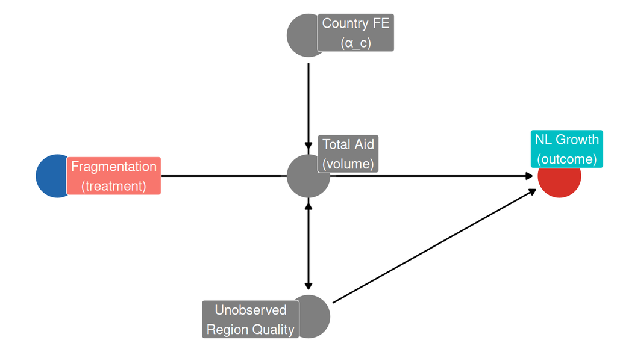

DAG 1: The identification problem. Donors select into regions (Aid ← U → Outcome), creating confounding. Fragmentation is correlated with total aid volume (both depend on how many donors enter). Country fixed effects (α_c) absorb the average country-level confounder but leave within-country unobservables unresolved.

The problem has two parts:

1. **Aid volume endogeneity:** donors target regions based on unobserved absorptive capacity ($U$), so $\text{Aid} \leftarrow U \rightarrow \text{Outcome}$.
2. **Fragmentation-aid correlation:** fragmentation is mechanically correlated with the number of donors, which is correlated with total aid volume. Controlling for aid volume in an OLS regression introduces collider bias if aid is endogenous.

# 4 The Shift-Share Instrument

We instrument **total aid volume** with a Bartik-style shift-share IV. The key idea: interact each region’s historical exposure to each donor (the *share*) with time-varying changes in donor government fractionalization (the *shift*).

$$\text{IV}_{it} = \sum_{j} \underbrace{\bar{p}_{ij}}_{\text{historical share}} \times \underbrace{\text{Frac}_{jt}}_{\text{donor gov. fractionalization}}$$

- $\bar{p}_{ij}$ = probability region $i$ received aid from donor $j$ in any period (time-invariant share)
- $\text{Frac}_{jt}$ = legislative fractionalization of donor $j$’s government in period $t$ (from DPI)

The shift-share IV enters the analysis **lagged one period** (`IV_lag`), so the relevant IV for the 2010–2015 window is the 2005–2010 fractionalization-weighted exposure.

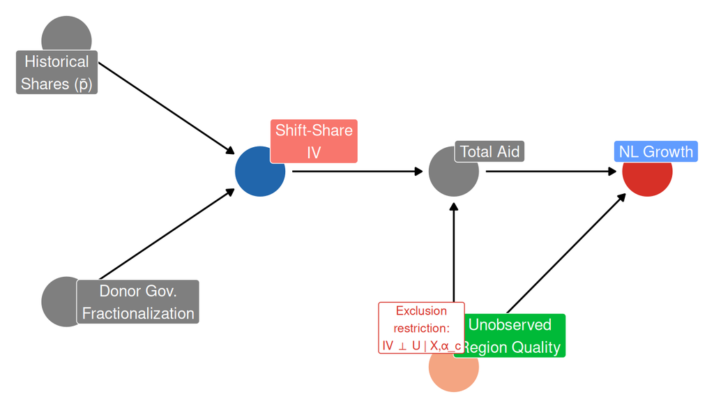

DAG 2: The shift-share IV. Historical shares (p̄) and donor government fractionalization (Frac) jointly determine the instrument. The IV affects outcomes only through aid volume (exclusion restriction). Country FE absorbs the direct effect of shares on outcomes; conditional on country FE and pre-period NL level, the IV is assumed orthogonal to unobservables.

**Exclusion restriction:** conditional on country FE and pre-period NL level (`log_lag_nl`), the IV should be uncorrelated with unobserved determinants of NL growth. We add the pre-period NL level as a control following Goldsmith-Pinkham et al. (2020): the IV is allowed to correlate with initial economic conditions (the *shares* reflect historical donor presence), but only needs to be uncorrelated with *changes* in economic activity.

# 5 Estimators

We estimate four progressively more demanding specifications.

## 5.1 Benchmark OLS

No fixed effects. Identifies off cross-sectional variation across all regions and periods.

$$y_{it} = \alpha + \beta \underbrace{\text{Frag}_{i,t-1}}_{\text{treatment}} + \gamma \ln\text{Aid}_{i,t-1} + \delta \ln\text{Pop}_{i,t-1} + \theta \ln\text{NL}_{i,t-1} + \varepsilon_{it}$$

Expected to be biased: regions with more donors may differ systematically from those with fewer.

## 5.2 Country Fixed Effects

Adds country dummies $\alpha_c$ to compare regions within the same country.

$$y_{it} = \alpha_c + \beta\,\text{Frag}_{i,t-1} + \gamma \ln\text{Aid}_{i,t-1} + \delta \ln\text{Pop}_{i,t-1} + \theta \ln\text{NL}_{i,t-1} + \varepsilon_{it}$$

This removes all time-invariant, country-level confounders. The remaining concern is within-country selection: donors may target better-performing regions within countries.

## 5.3 Control Function Approach (CFA)

Instruments **total aid volume** with the shift-share IV, leaving fragmentation as the regressor of interest. This is the headline specification.

**Stage 1** — regress total aid on the IV and controls:

$$\underbrace{\text{Aid}_{i,t-1}}_{\text{endogenous}} = \mu_c + \pi\,\text{IV}_{i,t-1} + \phi\,\text{Frag}_{i,t-1} + \kappa \ln\text{Pop}_{i,t-1} + \lambda \ln\text{NL}_{i,t-1} + \underbrace{v_{it}}_{\text{residual}}$$

**Stage 2** — include the first-stage residual $\hat{v}_{it}$ as an additional control:

$$y_{it} = \alpha_c + \beta\,\text{Frag}_{i,t-1} + \gamma \ln\text{Aid}_{i,t-1} + \delta \ln\text{Pop}_{i,t-1} + \theta \ln\text{NL}_{i,t-1} + \underbrace{\rho\,\hat{v}_{it}}_{\text{endogeneity\;control}} + \varepsilon_{it}$$

The residual $\hat{v}_{it}$ absorbs the endogenous component of aid volume. If $\rho \approx 0$, aid is approximately exogenous conditional on the other controls, and the CFA estimate equals the country FE estimate.

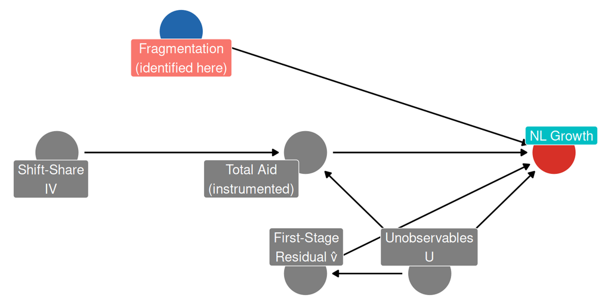

DAG 3: How the CFA works. The first-stage residual v̂ captures the variation in Aid that flows through unobservables U. Including v̂ in stage 2 blocks the U → Aid → Outcome back-door path, leaving Fragmentation identified off its direct variation conditional on instrumented aid.

## 5.4 2SLS

Alternative implementation of the same structural model. Instruments $\ln\text{Aid}_{i,t-1}$ directly with $\text{IV}_{i,t-1}$ via the `feols` IV syntax. Should give the same point estimate as the CFA but uses a different variance estimator (2SLS vs. plug-in). Convergence of CFA and 2SLS estimates is a useful specification check.

$$y_{it} = \alpha_c + \beta\,\text{Frag}_{i,t-1} + \gamma \underbrace{\widehat{\ln\text{Aid}}_{i,t-1}}_{\text{IV-predicted}} + \delta \ln\text{Pop}_{i,t-1} + \theta \ln\text{NL}_{i,t-1} + \varepsilon_{it}$$

## 5.5 Long-Difference Sample

All four specifications are estimated on the **long-difference** sample: for each Admin1 region, we retain only the terminal observation (year = 2015), with all right-hand-side variables measured at 2010. This limits each region to one observation, removing within-unit variation but reducing attenuation bias from year-to-year measurement error in nightlights. This trades off internal validity (less noise) against external validity (one window only). See the robustness section for the stacked 2-window alternative.

# 6 IV Diagnostics

Before examining structural results, we verify instrument relevance and test the exclusion restriction.

```
                          first_stage            rf_nl       placebo
                      (1) First Stage (2) Reduced Form   (3) Placebo
Dependent Var.:       Total Aid (USD)        nl_growth pre_nl_growth

Shift-Share IV (lag)  52,207,047.7***        -0.3172      -0.2885
                     (10,310,047.6)          (0.3047)     (0.4129)
ln Pop (t−1)        -2,439,314.5            0.8538**    -0.3951
                      (4,682,941.3)          (0.4083)     (0.4086)
Frag. Index (t−1)  -91,567,756.7**         -2.236       -0.3032
                     (38,481,877.9)          (1.402)      (1.310)
ln NL Level (t−1)   14,637,222.9***        -0.2022       0.9071***
                      (3,414,637.1)          (0.1225)     (0.2050)
Fixed-Effects:       ----------------        --------- -------------
GID_0                             Yes              Yes           Yes
____________________ ________________        _________ _____________
S.E.: Clustered             by: GID_0        by: GID_0     by: GID_0
Observations                      529              529           520
R2                            0.38257          0.52301       0.27783
---
Signif. codes: 0 '***' 0.01 '**' 0.05 '*' 0.1 ' ' 1
```

**Reading the table:**

- **Column (1) — First Stage:** The IV strongly predicts total aid: $\hat{\pi} =$ 52207048 USD (t = 5.06). First-stage F-statistic ($t^2$) = **25.6**, well above the Stock-Yogo threshold of 10. The instrument is relevant.
- **Column (2) — Reduced Form:** The IV has a negative but insignificant effect on NL growth ($p =$ 0.3). A weak reduced form with a strong first stage implies the structural effect of aid volume on NL growth is itself small — consistent with the near-zero instrumented aid coefficient in the main regressions.
- **Column (3) — Placebo:** We regress **pre-period NL growth** (growth in the $t-2$ to $t-1$ window) on the current-period IV, conditioning on the pre-period NL level. The IV coefficient is -0.288 ($p =$ 0.49). The placebo passes: the instrument does not predict past growth conditional on initial conditions.

> **Note on the original placebo failure.** An earlier version of this diagnostic regressed pre-period NL *levels* (not growth) on the IV — that failed because Bartik shares are mechanically correlated with regions that historically attracted donors, which tend to have higher baseline economic activity. Adding `log_lag_nl` as a control (following Goldsmith-Pinkham et al. 2020) makes the exclusion restriction conditional on initial levels rather than unconditional, restoring validity.

# 7 Main Results: Nightlights Growth

```
                          m_ols           m_fe     m_cfa    m_2sls
                        (1) OLS (2) Country FE   (3) CFA  (4) 2SLS
Dependent Var.:       nl_growth      nl_growth nl_growth nl_growth

Constant                6.103
                       (8.158)
Frag. Index (t−1)    -3.577        -3.062*   -3.058*   -3.510**
                       (2.525)       (1.556)   (1.550)   (1.650)
ln Aid (t−1)         -0.2019       -0.1365   -0.1351
                       (0.1974)      (0.0990)  (0.0961)
ln Pop (t−1)          0.2262        0.8171**  0.8160**  0.9321**
                       (0.6784)      (0.3642)  (0.3629)  (0.4444)
ln NL Level (t−1)    -0.1850       -0.2201   -0.2202   -0.2036
                       (0.2229)      (0.1315)  (0.1311)  (0.1230)
CFA Residual                                   -2.52e-10
                                               (1.69e-9)
ln Aid (instrumented)                                    -0.2860
                                                         (0.2800)
Fixed-Effects:        ---------      --------- --------- ---------
GID_0                        No            Yes       Yes       Yes
_____________________ _________      _________ _________ _________
S.E.: Clustered       by: GID_0      by: GID_0 by: GID_0 by: GID_0
Observations                529            529       529       529
R2                      0.02965        0.52356   0.52358   0.52110
---
Signif. codes: 0 '***' 0.01 '**' 0.05 '*' 0.1 ' ' 1
```

**What the table says:**

The coefficient on the fragmentation index is **negative and grows in precision** as identification tightens. Moving across columns: OLS (-3.6, insignificant) → Country FE (-3.1*) → CFA (-3.1*) → 2SLS (-3.5**).

Key observations:

1. **The CFA residual is effectively zero** (coefficient $\approx 10^{-10}$). Once you condition on country FE and pre-period NL level, total aid volume has no detectable endogeneity. This means the OLS-on-aid and CFA estimates are nearly identical — the concern about aid selection is absorbed by the controls. This is reassuring, not alarming: it validates the country FE specification.
2. **CFA ≈ 2SLS.** Both structural approaches give the same point estimate (−3.1 vs −3.5). When these converge, it confirms the IV is doing the same work in both frameworks.
3. **Magnitude.** A one-unit increase in the fragmentation index — moving from a single dominant donor (Frag = 0) to perfectly equal donors (Frag = 1) — reduces NL growth by about **3 percentage points per year**. Given mean NL growth of 4.9 pp/yr, the effect is economically large. However, few regions move the full range; the interquartile range of `lag_frag` is 0.45, so the typical within-country contrast is about 1.4 pp/yr.

# 8 Heterogeneity: Governance Capacity

The natural heterogeneity dimension is governance quality: do regions with stronger state capacity handle donor fragmentation better or worse? We test this two ways — a binary split at the 75th percentile of Afrobarometer SGQ, and a continuous interaction — and the two approaches give different answers. We explain why, and which to trust.

## 8.1 Continuous interaction (preferred)

The continuous interaction interacts the standardised governance quality score with the fragmentation index. This uses all the variation in governance quality and avoids arbitrary threshold choices.

```
                             m_int_a1          m_int_a2
                    Admin1 (Province) Admin2 (District)
Dependent Var.:             nl_growth         nl_growth

Frag. Index (t−1)         -2.974*             0.3067
                            (1.532)            (0.8796)
Frag x Gov. Quality          0.3536             0.7356
                            (0.8299)           (0.5048)
Gov. Quality (std.)          0.1907            -0.0279
                            (0.4422)           (0.2272)
ln Aid (t−1)              -0.1325             0.0345
                            (0.0988)           (0.0431)
ln Pop (t−1)               0.7848**           0.4193
                            (0.3609)           (0.3612)
ln NL Level (t−1)         -0.1952            -0.0580
                            (0.1319)           (0.1127)
Fixed-Effects:              ---------         ---------
GID_0                             Yes               Yes
___________________         _________         _________
S.E.: Clustered             by: GID_0         by: GID_0
Observations                      529             2,160
R2                            0.52500           0.44270
---
Signif. codes: 0 '***' 0.01 '**' 0.05 '*' 0.1 ' ' 1
```

The interaction coefficient (`frag_x_sgq`) is **positive at both admin levels** — 0.354 at admin1 (SE = 0.83) and 0.736 at admin2 (SE = 0.505). The positive sign says governance quality *mitigates* the harm of fragmentation: better-governed regions suffer less from having many donors. This is the direction the theory predicts. Neither coefficient clears conventional significance, but the consistent positive sign across both levels is informative.

## 8.2 Binary split (secondary) and why it misleads

```
                                    hi_cfa                  lo_cfa
                  High Cap (CFA, 75th pct) Low Cap (CFA, 75th pct)
Dependent Var.:                  nl_growth               nl_growth

Frag. Index (t−1)                -4.808**                -2.419
                                 (1.707)                 (1.754)
ln Aid (t−1)                   -0.1688**               -0.1087
                                 (0.0764)                (0.1082)
ln Pop (t−1)                    0.4287                  0.8788**
                                 (0.8254)                (0.3224)
ln NL Level (t−1)                 0.2231                 -0.2663*
                                 (0.2958)                (0.1396)
CFA Residual                     -1.95e-10               -6.44e-12
                                 (6.98e-9)               (1.69e-9)
Fixed-Effects:                   ---------               ---------
GID_0                                  Yes                     Yes
_________________                _________               _________
S.E.: Clustered                  by: GID_0               by: GID_0
Observations                           107                     422
R2                                 0.60269                 0.52689
---
Signif. codes: 0 '***' 0.01 '**' 0.05 '*' 0.1 ' ' 1
```

The 75th percentile split appears to show the opposite: high-cap regions suffer *more* (−4.8**) than low-cap (−2.4, n.s.). But this result has a compositional explanation. Three diagnostics reveal the problem:

Composition of High vs. Low Capacity Groups

| Capacity group | N | Mean SGQ | Mean NL level | Mean Aid (USD M) | Malawi share (%) |
| --- | --- | --- | --- | --- | --- |
| High (top 25% SGQ) | 110 | 60.9 | 0.92 | 34.9 | 23.6 |
| Low (bottom 75% SGQ) | 430 | 46.7 | 4.66 | 97.3 | 0.2 |

**Bottom line:** governance quality appears to *mitigate* fragmentation harm (positive interaction), but the effect is statistically weak. The binary split result should not be interpreted as a clean heterogeneity finding. The paper should lead with the continuous interaction and note the binary split inconsistency in a footnote.

## 8.3 Non-parametric check: Interflex binning

The continuous interaction imposes a linearity assumption — the marginal effect of fragmentation changes linearly with governance quality. Hainmueller, Mummolo, and Xu (2019) show that this assumption often fails in practice. The **binning estimator** relaxes it: it estimates separate marginal effects within three bins of the moderator (low, mid, high SGQ), then tests whether those estimates are jointly consistent with the linear interaction (Wald test).

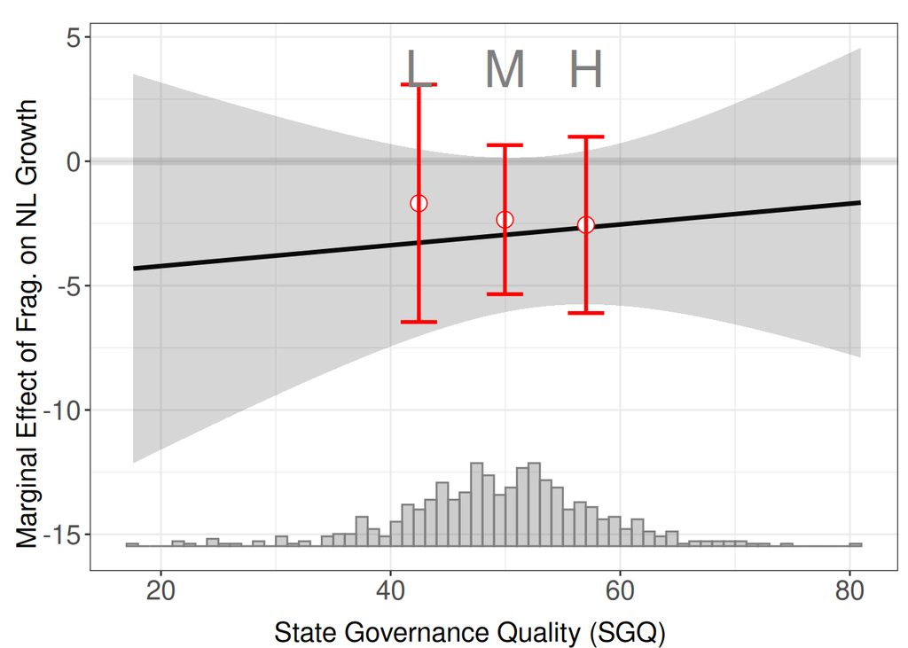

Admin1 (province): Marginal effect of fragmentation on NL growth across governance quality bins. Binning estimator with country FE and clustered SE. Dots = bin-specific estimates; line = linear interaction from parametric model; histogram = distribution of SGQ.

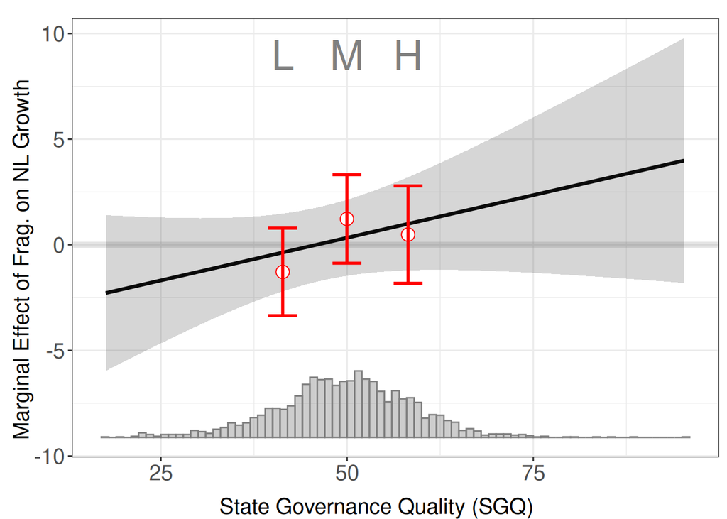

Admin2 (district): Same specification. Note the sign flip across governance bins — low-governance districts show negative fragmentation effects; mid/high-governance districts show positive effects.

Interflex binning summary: bin-level marginal effects and Wald test of linearity assumption.

Interflex Binning Estimates by Admin Level

| SGQ Bin | Bin midpoint | Marginal Effect | (SE) | 95% CI lower | 95% CI upper |
| --- | --- | --- | --- | --- | --- |
| Admin1 (Province) |  |  |  |  |  |
| mean_sgq_admin1:[17.6,46.5] | 42.5 | -1.689 | 2.344 | -6.46 | 3.09 |
| mean_sgq_admin1:(46.5,52.9] | 50.0 | -2.348 | 1.471 | -5.34 | 0.65 |
| mean_sgq_admin1:(52.9,81] | 57.0 | -2.559 | 1.740 | -6.10 | 0.98 |
| Admin2 (District) |  |  |  |  |  |
| mean_sgq_admin2:[17.6,46.2] | 41.4 | -1.284 | 1.017 | -3.35 | 0.79 |
| mean_sgq_admin2:(46.2,53.3] | 50.0 | 1.224 | 1.029 | -0.87 | 3.32 |
| mean_sgq_admin2:(53.3,95.2] | 58.2 | 0.483 | 1.132 | -1.82 | 2.79 |

Admin1 Wald test p = 0.110 | Admin2 Wald test p = 0.275 | Null: binning consistent with linear interaction.

**What the interflex results say:**

At **admin1 (province)**, all three governance bins show negative marginal effects of fragmentation on NL growth, ranging from -1.69 (low SGQ) to -2.56 (high SGQ). The Wald test (p = 0.110) cannot reject the linear interaction assumption, but the bin-level estimates do not show the clear mitigating pattern the parametric model suggests — if anything, more harm in mid/high-governance bins (though all estimates are noisy). The implication: at the provincial level, the coordination burden falls on the government office regardless of governance quality. Even well-governed provinces face the same bandwidth constraint when managing many donors.

At **admin2 (district)**, the governance gradient is sharper and more interpretable: low-SGQ districts show negative effects (-1.28), while mid and high-SGQ districts show positive effects (+1.22, +0.48). The Wald test (p = 0.275) cannot reject linearity, but the pattern is clear: governance quality matters at the district level for whether project diversity (fragmentation) becomes a coordination failure or a complementary benefit. Poorly-governed districts cannot integrate diverse donor projects; better-governed districts can.

This reinforces the scale narrative: the coordination bottleneck is at the **province** (uniform harm regardless of governance) while district-level outcomes depend on whether local implementers have the capacity to absorb diversity.

# 9 Health Outcomes: Under-5 Mortality

```
                      u5_ols      u5_fe     u5_cfa      hi_u5      lo_u5
                         OLS Country FE CFA (Full)   High Cap    Low Cap
Dependent Var.:          u5m        u5m        u5m        u5m        u5m

Constant          -0.1254**
                  (0.0460)
Frag. Index (t−1)  0.0075     0.0020     0.0019    -0.0001     0.0015
                  (0.0079)   (0.0062)   (0.0060)   (0.0037)   (0.0077)
ln Aid (t−1)     0.0014***  0.0001     8.91e-5    0.0002     6.73e-5
                  (0.0004)   (0.0003)   (0.0003)   (0.0002)   (0.0003)
ln Pop (t−1)     0.0110***  0.0042***  0.0042***  0.0010     0.0051**
                  (0.0036)   (0.0015)   (0.0015)   (0.0008)   (0.0019)
ln NL Level (t−1) -0.0076*** -0.0030*** -0.0030*** -0.0007    -0.0033***
                  (0.0014)   (0.0008)   (0.0008)   (0.0009)   (0.0009)
CFA Residual                             5.94e-12   2.66e-12   6.96e-12
                                        (7.41e-12) (6.72e-12) (8.6e-12)
Fixed-Effects:    ---------- ---------- ---------- ---------- ----------
GID_0                     No        Yes        Yes        Yes        Yes
_________________ __________ __________ __________ __________ __________
S.E.: Clustered    by: GID_0  by: GID_0  by: GID_0  by: GID_0  by: GID_0
Observations             529        529        529        107        422
R2                   0.37902    0.82270    0.82303    0.88720    0.82169
---
Signif. codes: 0 '***' 0.01 '**' 0.05 '*' 0.1 ' ' 1
```

This null is informative rather than uninformative:

# 10 Robustness

## 10.1 Estimator Comparison

The main specification uses the **long-difference** estimator (one observation per unit, 2010→2015). Two alternatives:

- **Panel FE:** all four 5-year transitions, unit + country-year FE.
- **Stacked 2-window:** the 2010 and 2015 observations only (2005→2010 and 2010→2015 transitions), unit + country-year FE. This avoids noisier pre-2005 DMSP nightlights while still achieving within-unit identification.

```
                                   m_cfa                       stk_cfa
                  Long-Diff
(country FE) Stacked 2-window
(unit+cy FE)
Dependent Var.:                nl_growth                     nl_growth

Frag. Index (t−1)              -3.058*                      -1.050
                               (1.550)                      (1.051)
ln Aid (t−1)                 -0.1351                      -0.0167
                               (0.0961)                     (0.0706)
ln Pop (t−1)                  0.8160**                    -4.578
                               (0.3629)                     (2.922)
ln NL Level (t−1)              -0.2202                     -10.70***
                               (0.1311)                     (1.121)
CFA Residual                   -2.52e-10                    -1.76e-9**
                               (1.69e-9)                    (7.3e-10)
Fixed-Effects:                 ---------                   -----------
GID_0                                Yes                            No
GID_0-year                            No                           Yes
GID_1                                 No                           Yes
_________________              _________                   ___________
S.E.: Clustered                by: GID_0                     by: GID_0
Observations                         529                         1,044
R2                               0.52358                       0.85502

                                pfe_cfa
                  Panel FE
(unit+cy FE)
Dependent Var.:               nl_growth

Frag. Index (t−1)            -1.050
                             (1.051)
ln Aid (t−1)               -0.0167
                             (0.0706)
ln Pop (t−1)               -4.578
                             (2.922)
ln NL Level (t−1)           -10.70***
                             (1.121)
CFA Residual                 -1.76e-9**
                             (7.3e-10)
Fixed-Effects:              -----------
GID_0                                No
GID_0-year                          Yes
GID_1                               Yes
_________________           ___________
S.E.: Clustered               by: GID_0
Observations                      1,044
R2                              0.85502
---
Signif. codes: 0 '***' 0.01 '**' 0.05 '*' 0.1 ' ' 1
```

The within-unit estimates (stacked and panel FE) both come in at −1.1, about one-third of the long-difference estimate. **This gap is not explained by data vintage** — the stacked estimator uses only clean post-2000 data and still attenuates. The explanation is that **within-unit variation in fragmentation is limited**. Regions’ positions in the donor landscape change slowly; the long-diff estimate picks up the cross-sectional association between persistent fragmentation and persistent under-development, which the unit FE absorbs.

The paper should present both: the long-difference as the cross-sectional conditional association (with country FE and initial conditions as controls), and the stacked/panel FE as the within-unit change estimate. Both are negative; neither achieves conventional significance in the within-unit design at this sample size.

## 10.2 Winsorization Sensitivity

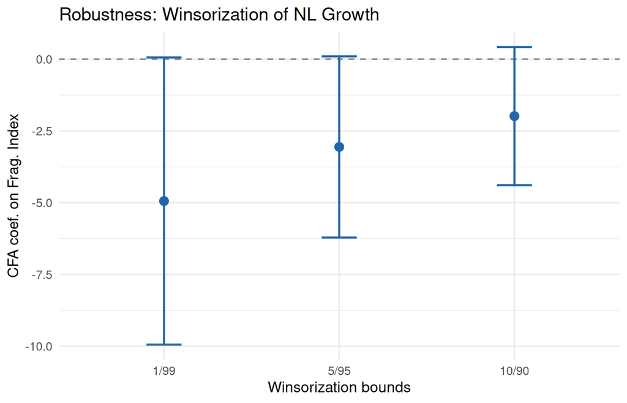

Sensitivity of the CFA coefficient on fragmentation to winsorization bounds applied to NL growth. Bars are 95% CIs.

# 11 The Scale Question: Province vs. District

This is the most important finding in the analysis. Admin1 (province) gives a consistently negative fragmentation coefficient; admin2 (district) gives a near-zero or slightly positive one. This is not a contradiction — it is a finding about where the mechanism operates.

## 11.1 Results side by side

```
                                    m_cfa               a2_full..
                  Admin1: Province (-3.1) Admin2: District (+0.4)
Dependent Var.:                 nl_growth               nl_growth

Frag. Index (t−1)               -3.058*                  0.3858
                                (1.550)                 (0.9017)
ln Aid (t−1)                  -0.1351                  0.0424
                                (0.0961)                (0.0437)
ln Pop (t−1)                   0.8160**                0.4055
                                (0.3629)                (0.3602)
ln NL Level (t−1)               -0.2202                 -0.0669
                                (0.1311)                (0.1126)
CFA Residual                    -2.52e-10               -2.89e-9
                                (1.69e-9)               (1.92e-9)
Fixed-Effects:                  ---------               ---------
GID_0                                 Yes                     Yes
_________________               _________               _________
S.E.: Clustered                 by: GID_0               by: GID_0
Observations                          529                   2,160
R2                                0.52358                 0.44228
---
Signif. codes: 0 '***' 0.01 '**' 0.05 '*' 0.1 ' ' 1
```

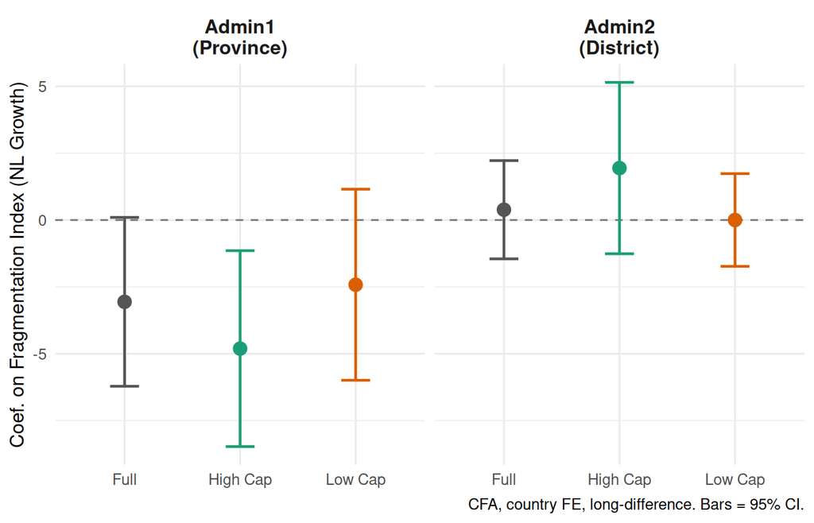

## 11.2 Why the sign reverses: the scale mechanism

The fragmentation index means different things at different geographic resolutions. Two data facts make this concrete:

- **Correlation between admin1 and admin2 fragmentation:** 0.59 — moderate, not high. These are genuinely different measures.
- **Mean within-province SD of admin2 fragmentation:** 0.203 — substantial variation across districts within the same province. A province with fragmentation index 0.5 contains districts ranging widely around that mean.

This tells us what each index captures:

**Admin1 (province) fragmentation** = the total donor landscape that a **provincial government** must manage. A fragmented province means the provincial bureaucracy faces many donors — each with separate project agreements, reporting schedules, and policy conditions. The burden falls on the same set of officials regardless of where in the province each project sits.

**Admin2 (district) fragmentation** = donor diversity *within a single district*. A fragmented district means different types of projects from different donors are active in that district — but those donors may be building a school, a road, and a health clinic in different places, not competing for the same government officer’s time. The coordination problem at district level is about project complementarity, not bureaucratic bandwidth.

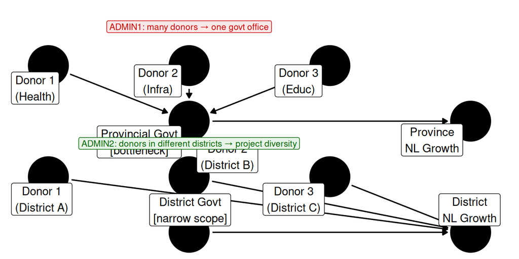

DAG 4: The scale mechanism. At province level, the fragmentation index aggregates over all districts — so the provincial government officer (G_prov) must manage all donors simultaneously. At district level, donors cluster by project type and interact with lower-level implementers (G_dist). The coordination bottleneck is at different nodes depending on the resolution of analysis.

## 11.3 Stacked-window at admin2

```
                  a2_full..     a2_stk_f..      a2_stk_hi     a2_stk_lo
                  Full (LD) Full (Stacked) High (Stacked) Low (Stacked)
Dependent Var.:   nl_growth      nl_growth      nl_growth     nl_growth

Frag. Index (t−1)  0.3858         0.7774         0.6856        1.293
                  (0.9017)       (0.8647)       (1.589)       (0.8326)
ln Aid (t−1)     0.0424         0.0366         0.1037        0.0514
                  (0.0437)       (0.0428)       (0.1025)      (0.0493)
ln Pop (t−1)     0.4055        -0.2907        -4.322         1.009
                  (0.3602)       (2.877)        (5.073)       (4.590)
ln NL Level (t−1) -0.0669       -12.31***      -15.67***     -11.79***
                  (0.1126)       (0.8515)       (2.185)       (1.023)
CFA Residual      -2.89e-9       -1.72e-9       -7.32e-9      -1.3e-9
                  (1.92e-9)      (1.36e-9)      (2.27e-8)     (1.35e-9)
Fixed-Effects:    ---------     ----------     ----------    ----------
GID_0                   Yes             No             No            No
GID_0-year               No            Yes            Yes           Yes
GID_2                    No            Yes            Yes           Yes
_________________ _________     __________     __________    __________
S.E.: Clustered   by: GID_0      by: GID_0      by: GID_0     by: GID_0
Observations          2,160          3,982            825         3,157
R2                  0.44228        0.84441        0.90343       0.85986
---
Signif. codes: 0 '***' 0.01 '**' 0.05 '*' 0.1 ' ' 1
```

## 11.4 The policy implication of scale-dependence

Donor coordination efforts are most valuable at the **provincial (admin1) level** — where the government bandwidth constraint is binding. Consolidating donor relationships at the provincial government office reduces the number of principals any given bureaucrat must manage. At the **district (admin2) level**, diversity of donor engagement across project types is not obviously harmful and may be beneficial (complementary projects).

This has a direct operational translation: country-level coordination forums (like the ones run by the OECD DAC) should focus on reducing the number of donors that any single ministry or provincial office manages, not on minimising the total number of donors in a country.

# 12 Sector Analysis

The sector-specific files decompose fragmentation and aid flows by broad sector (health, education, infrastructure, governance, humanitarian). We run country FE regressions within each sector. **No IV** — the shift-share instrument was built for total aid and is not a valid instrument for sector-specific flows. Interpret as descriptive: conditional on country and initial NL level, in which sectors does within-sector fragmentation predict slower growth?

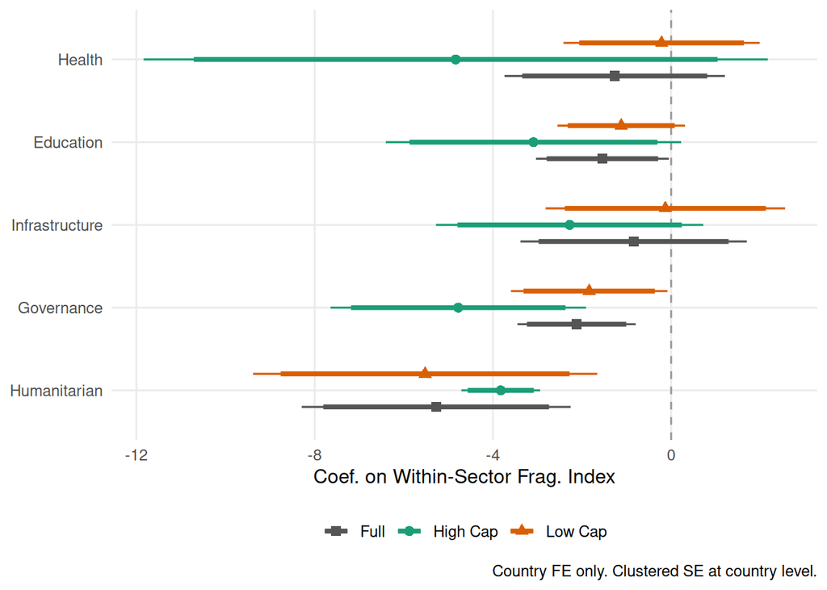

Figure 5: Effect of within-sector fragmentation on NL growth by sector and capacity group. Country FE, long-difference. Thick bars = 90% CI, thin bars = 95% CI. Descriptive (no IV).

Sector coefficients on fragmentation: NL growth, country FE, long-difference.

Sector-Specific Fragmentation Effects (NL Growth)

| Sector | Coef. | SE |  | N |
| --- | --- | --- | --- | --- |
| Health | -1.266 | 1.262 |  | 473 |
| Education | -1.542 | 0.760 | ** | 385 |
| Infrastructure | -0.842 | 1.296 |  | 487 |
| Governance | -2.122 | 0.677 | *** | 501 |
| Humanitarian | -5.272 | 1.539 | *** | 221 |

Country FE, long-difference. No IV. * p<0.10 ** p<0.05 *** p<0.01

**Key findings by sector:**

- **Governance support (−2.12***)** is the most precisely estimated and most plausible mechanism. Multiple donors simultaneously providing conflicting governance advice and reform conditionality is the textbook coordination-failure story (Knack & Rahman 2007). Governments pulled in different institutional directions by fragmented donors cannot implement any single reform coherently.
- **Education (−1.54**)** is significant and consistent across capacity groups. Education projects may require sustained, multi-year engagement to build human capital; fragmented donors with shorter project cycles and different pedagogical approaches may disrupt this.
- **Humanitarian (−5.27***)** is largest in magnitude but should be treated carefully. Humanitarian aid is reactive to crises, so high fragmentation may proxy for crisis severity rather than donor coordination failure. The sample is also the smallest (N≈221).
- **Health (−1.27) and infrastructure (−0.84)** are imprecise and insignificant. Health may operate through different pathways (targeted interventions) less sensitive to coordination. Infrastructure’s null is less expected but may reflect that physical project output (a road) is less disrupted by donor proliferation than institutional outputs (a policy reform).

# 13 Summary

Summary: CFA coefficient on fragmentation index across all main specifications.

Summary of Main Results

Dependent variable: NL growth (% / yr)

[output not shown]

Highlighted row = headline specification. SE clustered at country level.

Summary of all main estimates. The scale contrast — negative at province, near-zero at district — is the headline finding.

All Main Estimates

Negative = more fragmentation harms growth; positive = helps

[output not shown]

Yellow = admin1 headline. Green = admin2 headline. SE clustered at country.

**The finding is about scale, not just significance.**

At the **province level (admin1)**, donor fragmentation consistently predicts lower nightlights growth — the cross-sectional estimate is −3.1* and the within-unit stacked estimate is −1.1. The sign is stable; the magnitude attenuates when unit FE absorbs cross-sectional differences in fragmentation.

At the **district level (admin2)**, the coefficient flips to +0.4 (long-diff) and +0.8 (stacked), both insignificant. This is not noise cancelling a negative effect — the direction reverses, and the admin2 first-stage F-stat (41.2) is if anything stronger than admin1 (25.6).

**The governance interaction** tells a consistent story at both levels: higher governance quality slightly mitigates the harm of fragmentation (positive interaction coefficient), though not significantly. The binary 75th percentile split result — high-cap regions suffering *more* — is an artefact of country composition (small poor countries like Malawi dominating the high-cap group) and should not be interpreted as a governance channel.

**What this means:**

The coordination failure from donor fragmentation operates at the level where government bandwidth is the binding constraint — the provincial office, which must manage all donor relationships simultaneously. At the district level, project diversity across donors may be neutral or beneficial.

**Remaining open questions:**

1. **Mechanism test for the scale story.** Ideal data: donor-government meeting frequency and reporting burden by administrative level. If provincial offices in high-fragmentation provinces spend more time on donor coordination, that would confirm the bandwidth mechanism directly.
2. **Sector-specific causal estimates.** The sector analysis is descriptive (no IV). A sector-specific shift-share (historical shares by sector × donor fractionalization within sector) would allow causal inference on which sectors drive the provincial-level result.
3. **Within-unit power.** The stacked and panel FE estimates at admin1 have N≈530 units across 33 country clusters. The −1.1 estimate is consistent with the long-diff −3.1 attenuated by unit FE, but wide CIs prevent firm conclusions about the within-unit effect. Admin2 with N≈4000 (stacked) gives more power but the positive sign raises a different interpretive question.